# gBlock selection

crystal_full_contig_d26_seqvar

Published

August 19, 2026

Selecting sequences to order as gBlocks.

Source table is `results/orthogonal_metrics/survivors_with_orthogonal_metrics_gblocks.csv`, produced by `scripts/make_gblocks.py`. Local copy in `data/`.

```python
from pathlib import Path
import pandas as pd
import matplotlib.pyplot as plt
import numpy as np
import itertools
from scipy.cluster.hierarchy import linkage, fcluster, dendrogram
from scipy.spatial.distance import squareform

plt.rcParams.update({"figure.dpi": 140, "savefig.bbox": "tight", "font.size": 9})
pd.set_option("display.max_colwidth", 40)

OUT = Path("outputs"); OUT.mkdir(exist_ok=True)
df = pd.read_csv(Path("data") / "survivors_with_orthogonal_metrics_gblocks.csv")
IPSAE = "rep_ipsae_min_median"
```

## 1 Tier A pool

```python
steered = df[df["row_type"] == "steered"].copy()
regions = steered["designed_residues"].str.split("|")
steered["region1"] = regions.str[0]
steered["region2"] = regions.str[1]

tier_a = steered[steered["cross_tier"] == "A"].sort_values("cross_rank_by_composite").reset_index(drop=True)
tier_a.to_csv(OUT / "tier_A_candidates.csv", index=False)

pd.crosstab(steered["cross_tier"], "n").reindex(["A", "B", "C", "none"])
```

| col_0 cross_tier | n |
| --- | --- |
| A | 54 |
| B | 18 |
| C | 4 |
| none | 51 |

- 54 of 127 steered sequences are Tier A.
- All 54 pass the orthogonal filters.
- All 54 designed sequences are distinct.

```python
tier_a[["mpnn_sequence", "cross_rank_by_composite", "cross_composite_score",
        IPSAE, "rep_outcome", "region1", "region2"]]
```

|  | mpnn_sequence | cross_rank_by_composite | cross_composite_score | rep_ipsae_min_median | rep_outcome | region1 | region2 |
| --- | --- | --- | --- | --- | --- | --- | --- |
| 0 | design_26_seq_40 | 1.0 | 0.721450 | 0.7656 | no_reversion | AVALLESERDDGTTVKSIQ | EDMPRK |
| 1 | design_26_seq_119 | 2.0 | 0.699700 | 0.5824 | no_reversion | AVAVLESEADNGEVVTKIQ | EDMPAK |
| 2 | design_26_seq_99 | 3.0 | 0.676600 | 0.4051 | no_reversion | AVKLLESERDDGKKVYSIQ | ENMPKK |
| 3 | design_26_seq_33 | 4.0 | 0.669700 | 0.5382 | no_reversion | AVALLESERDDGTVVKSIQ | ESMPSK |
| 4 | design_26_seq_116 | 5.0 | 0.668000 | 0.4466 | no_reversion | AVKLLESEQDDGKTLKTIQ | EDMPAK |
| 5 | design_26_seq_6 | 6.0 | 0.663750 | 0.6035 | no_reversion | AVAVLESESDTGEVVKSIQ | ENMPAK |
| 6 | design_26_seq_18 | 7.0 | 0.658900 | 0.7461 | no_reversion | AVALLESERDDGTTVKKIQ | EDMPAK |
| 7 | design_26_seq_80 | 8.0 | 0.655100 | 0.4504 | no_reversion | AVALLESEQDDGTTLKTIQ | EDMPAK |
| 8 | design_26_seq_120 | 9.0 | 0.645150 | 0.0025 | pose_holds | AVALLESEQDNGETVNTIQ | EDMPAK |
| 9 | design_26_seq_104 | 10.0 | 0.643650 | 0.1452 | no_reversion | AVQLLESEGDNGEVLNSIQ | EDMPAK |
| 10 | design_26_seq_118 | 11.0 | 0.637450 | 0.0000 | no_reversion | AVKLLESEQDDGTTRLAIQ | ENMPAK |
| 11 | design_26_seq_22 | 12.0 | 0.625650 | 0.6486 | no_reversion | AVALLESESDSGEVVQSIL | EDMPAK |
| 12 | design_26_seq_28 | 13.0 | 0.624750 | 0.4505 | no_reversion | AVKLLESEQDNGEVLYSIQ | EDMPAK |
| 13 | design_26_seq_74 | 14.0 | 0.612200 | 0.5947 | no_reversion | AVALLESESDSGKTVKTIQ | EEMPAK |
| 14 | design_26_seq_61 | 15.0 | 0.590850 | 0.1267 | no_reversion | AVALLESESDSGKTVKRIQ | EDMPAK |
| 15 | design_26_seq_12 | 16.0 | 0.586750 | 0.6866 | no_reversion | AVKLLESERDDGTVVKKIQ | EDMPAK |
| 16 | design_26_seq_107 | 17.0 | 0.585050 | 0.8247 | no_reversion | AVALLEYPSDTGETVYKIQ | QDMPAK |
| 17 | design_26_seq_69 | 18.0 | 0.581950 | 0.0000 | no_reversion | AVALLESESDTGEVVYSIQ | ENMPSK |
| 18 | design_26_seq_29 | 19.0 | 0.577350 | 0.8086 | no_reversion | AVALLESESDTGETVLKIQ | EDLPAK |
| 19 | design_26_seq_113 | 20.0 | 0.569850 | 0.2437 | no_reversion | AVALLESESDSGETVKKIQ | EDLPAK |
| 20 | design_26_seq_1 | 21.0 | 0.566150 | 0.6767 | pose_holds | AVALLESETDSGETVNTIQ | EDMPAR |
| 21 | design_26_seq_92 | 22.0 | 0.561750 | 0.4756 | no_reversion | AVALLESEQDNGNTLLSIQ | EDMPAK |
| 22 | design_26_seq_127 | 23.0 | 0.560250 | 0.1149 | no_reversion | AVALLESESDNGTTVNSIQ | EDMPAK |
| 23 | design_26_seq_108 | 24.0 | 0.548200 | 0.6353 | no_reversion | AVALLDSPQDSGKTVQSIQ | EDMPAK |
| 24 | design_26_seq_17 | 25.0 | 0.539100 | 0.2488 | no_reversion | AVKLLESERDDGTVANAIQ | EDMPAK |
| 25 | design_26_seq_54 | 26.0 | 0.534700 | 0.7456 | no_reversion | AVRLLESEADDGSTVNRIQ | EDMPRK |
| 26 | design_26_seq_117 | 27.0 | 0.519450 | 0.7339 | no_reversion | AVALLESESDSGEVVKRIQ | EDMPSK |
| 27 | design_26_seq_68 | 28.0 | 0.513950 | 0.6289 | pose_holds | AVALLESERDDGKVLLSIQ | EDMPAK |
| 28 | design_26_seq_24 | 29.0 | 0.513900 | 0.6728 | no_reversion | AVALLEYESDTGKTVRQIQ | EDMPRK |
| 29 | design_26_seq_110 | 30.0 | 0.510700 | 0.5975 | no_reversion | AVKVLESDQDTGKTLTSIQ | EDMPAK |
| 30 | design_26_seq_125 | 31.0 | 0.510150 | 0.3613 | no_reversion | AVKLLESESDDGSVVKKIQ | EDMPAK |
| 31 | design_26_seq_96 | 32.0 | 0.503600 | 0.5593 | no_reversion | AVKLLESESDDGKVVKRIQ | EDMPRK |
| 32 | design_26_seq_93 | 33.0 | 0.489850 | 0.2008 | no_reversion | AVKLLEYESDTGETVLKIQ | EDMPAK |
| 33 | design_26_seq_56 | 34.0 | 0.477250 | 0.5110 | no_reversion | AVQLLESERDDGTVVKRIQ | EDMPRK |
| 34 | design_26_seq_62 | 35.0 | 0.444150 | 0.6353 | no_reversion | AVKLLESEQDNGKKVLKIQ | EDMPAK |
| 35 | design_26_seq_64 | 36.0 | 0.423750 | 0.6227 | pose_holds | AVAILESEQDDGTVSLSIQ | EEMPAK |
| 36 | design_26_seq_70 | 37.0 | 0.421250 | 0.3666 | pose_holds | AVRILESEQDDGKVMTKIQ | EDMPAK |
| 37 | design_26_seq_85 | 38.0 | 0.414600 | 0.6334 | no_reversion | AVKLLESESDSGKKVYSIQ | EDMPAK |
| 38 | design_26_seq_91 | 39.0 | 0.413900 | 0.2383 | no_reversion | AVKLLESEQDDGKTVHKIQ | EDMPAK |
| 39 | design_26_seq_11 | 40.0 | 0.413350 | 0.7691 | pose_holds | AVALLEYDSDDGTTVYKIQ | EDMPAK |
| 40 | design_26_seq_45 | 41.0 | 0.404950 | 0.3026 | no_reversion | AVALLESEQDDGTTQLSIQ | EEMPRK |
| 41 | design_26_seq_103 | 42.0 | 0.403050 | 0.5380 | pose_holds | AVALLESESDNGKTVYSIQ | EDMPAK |
| 42 | design_26_seq_87 | 43.0 | 0.394900 | 0.6150 | no_reversion | AAALLESEQDNGKTLETIQ | EDMPAK |
| 43 | design_26_seq_42 | 44.0 | 0.391300 | 0.7684 | no_reversion | AVALLVSESDDGKRVEKIQ | EDMPAK |
| 44 | design_26_seq_50 | 45.0 | 0.357600 | 0.7076 | pose_holds | AVALLESEQDNGKTRLSIQ | EDMPSK |
| 45 | design_26_seq_94 | 46.0 | 0.342950 | 0.0157 | no_reversion | AVALLESERDDGKTVLSIQ | QDMPAK |
| 46 | design_26_seq_13 | 47.0 | 0.341900 | 0.6202 | no_reversion | AVALLESERDDGKVLRKIQ | TDMPRK |
| 47 | design_26_seq_39 | 48.0 | 0.337500 | 0.1741 | no_reversion | AVAVLESERDDGTTVLSIQ | EDMPAK |
| 48 | design_26_seq_82 | 49.0 | 0.335150 | 0.7103 | no_reversion | AVALLESERDNGETVLTIQ | EDMPRK |
| 49 | design_26_seq_37 | 50.0 | 0.318675 | 0.4227 | pose_holds | AVALLESESDTGKKVLTIQ | EDMPAK |
| 50 | design_26_seq_81 | 51.0 | 0.309000 | 0.7575 | no_reversion | AVALLESEQDNGKTVKRIQ | EDMPAK |
| 51 | design_26_seq_19 | 52.0 | 0.301250 | 0.2231 | no_reversion | AVALLESEQDNGKTQLRIQ | TDLPSK |
| 52 | design_26_seq_109 | 53.0 | 0.292550 | 0.7388 | no_reversion | AVALLESESDNGKTVLKIQ | EDMPAK |
| 53 | design_26_seq_71 | 54.0 | 0.292400 | 0.5653 | no_reversion | AVALLESEADDGTTVLKIQ | ENMPAK |

## 2 SNK-EKE check

SNK-EKE is a published engineered Pikp-1 variant. Wild type region 2 is `SQANKD` and SNK-EKE is `EQAKED`. They differ at positions 1, 4 and 5.

The question is whether hits recovered that variant from training data.

```python
WT, SNK = "SQANKD", "EQAKED"
diff_pos = [i for i in range(6) if WT[i] != SNK[i]]

pd.DataFrame({
    "position": [i + 1 for i in diff_pos],
    "SNK-EKE residue": [SNK[i] for i in diff_pos],
    "n of 54 matching": [int((tier_a["region2"].str[i] == SNK[i]).sum()) for i in diff_pos],
})
```

|  | position | SNK-EKE residue | n of 54 matching |
| --- | --- | --- | --- |
| 0 | 1 | E | 50 |
| 1 | 4 | K | 0 |
| 2 | 5 | E | 0 |

- Position 1 matches in 50 of 54 candidates.
- Positions 4 and 5 match in zero candidates.
- No candidate matches more than one of the three.

```python
by_tier = (steered.assign(is_E=steered["region2"].str[0].eq("E"))
                  .groupby("cross_tier")["is_E"]
                  .agg(n="size", n_with_E="sum"))
by_tier["percent_E"] = (by_tier["n_with_E"] / by_tier["n"] * 100).round(1)
by_tier.reindex(["A", "B", "C", "none"])
```

| cross_tier | n | n_with_E | percent_E |
| --- | --- | --- | --- |
| A | 54 | 50 | 92.6 |
| B | 18 | 16 | 88.9 |
| C | 4 | 4 | 100.0 |
| none | 51 | 49 | 96.1 |

- E at position 1 appears in 119 of 127 steered sequences.
- Failures carry it at 96.1%, Tier A at 92.6%.
- No enrichment in hits, so it is not a recovered SNK-EKE signature.

**Keep all 54.**

## 3 ipSAE

```python
thresholds = [0.5, 0.6, 0.7, 0.8]
pd.DataFrame({
    "threshold": thresholds,
    "n above": [int((tier_a[IPSAE] > t).sum()) for t in thresholds],
})
```

|  | threshold | n above |
| --- | --- | --- |
| 0 | 0.5 | 32 |
| 1 | 0.6 | 24 |
| 2 | 0.7 | 12 |
| 3 | 0.8 | 2 |

- 32, 24, 12 and 2 candidates exceed 0.5, 0.6, 0.7 and 0.8.
- Highest value is 0.8247 (design_26_seq_107).
- Median is 0.5738.

```python
tier_a[tier_a["region2"].str[0] != "E"][
    ["mpnn_sequence", "region2", IPSAE, "cross_rank_by_composite"]]
```

|  | mpnn_sequence | region2 | rep_ipsae_min_median | cross_rank_by_composite |
| --- | --- | --- | --- | --- |
| 16 | design_26_seq_107 | QDMPAK | 0.8247 | 17.0 |
| 45 | design_26_seq_94 | QDMPAK | 0.0157 | 46.0 |
| 46 | design_26_seq_13 | TDMPRK | 0.6202 | 47.0 |
| 51 | design_26_seq_19 | TDLPSK | 0.2231 | 52.0 |

- The 4 candidates without E span 0.0157 to 0.8247.
- design_26_seq_107 is the highest ipSAE in the whole pool.

## 4 Diversity above ipSAE 0.6

All candidates share the design 26 backbone. Diversity comes only from the 25 designed positions.

```python
pool = tier_a[tier_a[IPSAE] > 0.6].sort_values(IPSAE, ascending=False).reset_index(drop=True).copy()
pool["designed"] = pool["region1"] + pool["region2"]
N_R1, N_POS = 19, 25

seqs = pool["designed"].tolist()
n = len(seqs)
D = np.zeros((n, n))
for i, j in itertools.combinations(range(n), 2):
    D[i, j] = D[j, i] = sum(a != b for a, b in zip(seqs[i], seqs[j]))
upper = D[np.triu_indices(n, 1)]

pd.DataFrame({"minimum": [upper.min()], "median": [np.median(upper)],
              "maximum": [upper.max()]}, index=["Hamming distance"])
```

|  | minimum | median | maximum |
| --- | --- | --- | --- |
| Hamming distance | 2.0 | 7.0 | 12.0 |

- 24 candidates, all distinct.
- Median pair differs at 7 of 25 designed positions.
- Closest pair differs at 2.

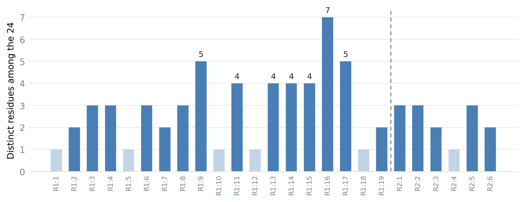

```python
INK, MUTED, BAR, QUIET = "#1f2933", "#7b8794", "#4a7fb5", "#c3d4e6"
heights = np.array([len({s[i] for s in seqs}) for i in range(N_POS)])
labels = [f"R1:{i+1}" if i < N_R1 else f"R2:{i-N_R1+1}" for i in range(N_POS)]

fig, ax = plt.subplots(figsize=(9, 3))
ax.bar(np.arange(N_POS), heights, width=0.62, linewidth=0,
       color=[BAR if h > 1 else QUIET for h in heights])
for x, h in enumerate(heights):
    if h >= 4:
        ax.text(x, h + 0.12, str(h), ha="center", va="bottom", fontsize=8, color=INK)
ax.axvline(N_R1 - 0.5, color=MUTED, linewidth=1, linestyle=(0, (4, 3)))
ax.set_xticks(range(N_POS)); ax.set_xticklabels(labels, rotation=90, fontsize=7)
ax.set_ylabel("Distinct residues among the 24", fontsize=9)
ax.set_yticks(range(0, heights.max() + 1))
ax.tick_params(length=0, colors=MUTED)
ax.grid(axis="y", color="#e4e7eb", linewidth=0.6); ax.set_axisbelow(True)
for side in ("top", "right", "left"):
    ax.spines[side].set_visible(False)
ax.spines["bottom"].set_color("#e4e7eb")
plt.show()
```

- Pale bars are positions fixed across all 24 candidates.
- Six of 25 positions never vary.
- R1:16 is most variable with 7 residues, then R1:9 and R1:17 with 5.

```python
Z = linkage(squareform(D), method="average")
pd.DataFrame([{"cut": t, "n clusters": len(set(fcluster(Z, t, criterion="distance"))),
               "largest": max(pd.Series(fcluster(Z, t, criterion="distance")).value_counts())}
              for t in range(2, 9)]).set_index("cut")
```

| cut | n clusters | largest |
| --- | --- | --- |
| 2 | 23 | 2 |
| 3 | 21 | 3 |
| 4 | 16 | 3 |
| 5 | 13 | 3 |
| 6 | 9 | 8 |
| 7 | 6 | 14 |
| 8 | 2 | 23 |

- At a 4-difference cut there are 16 clusters.
- The largest cluster holds 3 candidates.
- Clusters merge into large groups only at cut 6 and above.

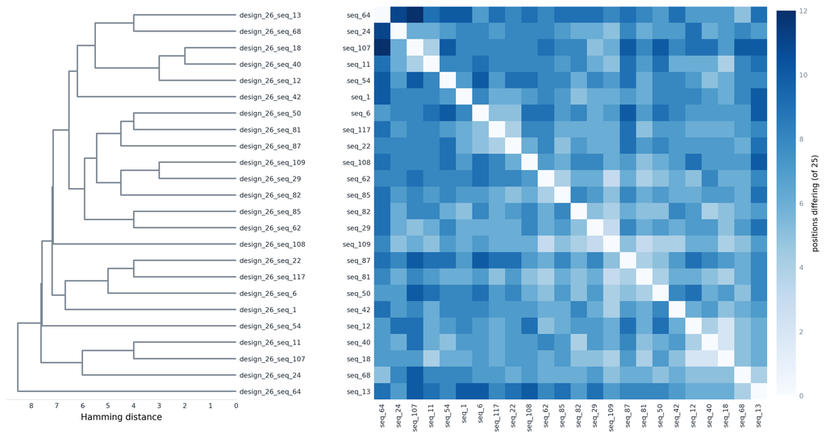

```python
pool["cluster"] = fcluster(Z, 4, criterion="distance")

fig, (ax_d, ax_h) = plt.subplots(1, 2, figsize=(12, 6.4),
                                 gridspec_kw={"width_ratios": [1, 2.1]})
dn = dendrogram(Z, labels=pool["mpnn_sequence"].tolist(), orientation="left",
                ax=ax_d, color_threshold=0, link_color_func=lambda _: MUTED)
ax_d.set_xlabel("Hamming distance", fontsize=9)
ax_d.tick_params(labelsize=7, length=0, colors=INK)
for side in ("top", "right", "left"):
    ax_d.spines[side].set_visible(False)
ax_d.spines["bottom"].set_color("#e4e7eb")

order = dn["leaves"]
tick = [pool["mpnn_sequence"][i].replace("design_26_", "") for i in order]
im = ax_h.imshow(D[np.ix_(order, order)], cmap="Blues", vmin=0, vmax=D.max())
ax_h.set_xticks(range(n)); ax_h.set_xticklabels(tick, rotation=90, fontsize=7)
ax_h.set_yticks(range(n)); ax_h.set_yticklabels(tick, fontsize=7)
ax_h.tick_params(length=0, colors=INK)
for side in ax_h.spines:
    ax_h.spines[side].set_visible(False)
cb = fig.colorbar(im, ax=ax_h, fraction=0.040, pad=0.02)
cb.set_label("positions differing (of 25)", fontsize=8)
cb.ax.tick_params(labelsize=7, length=0, colors=MUTED)
cb.outline.set_visible(False)
fig.tight_layout()
plt.show()
```

- Colour runs light for similar to dark for different.
- The white diagonal is each sequence against itself.
- Pale off-diagonal cells are rare, so there are no tight groups.

```python
np.fill_diagonal(D, np.inf)
pool["nearest"] = [pool["mpnn_sequence"][k].replace("design_26_", "") for k in D.argmin(axis=1)]
pool["nearest_distance"] = D.min(axis=1).astype(int)
np.fill_diagonal(D, 0)
pool.to_csv(OUT / "ipsae_pool_with_clusters.csv", index=False)

pool[["mpnn_sequence", IPSAE, "cross_rank_by_composite", "cluster",
      "nearest", "nearest_distance"]]
```

|  | mpnn_sequence | rep_ipsae_min_median | cross_rank_by_composite | cluster | nearest | nearest_distance |
| --- | --- | --- | --- | --- | --- | --- |
| 0 | design_26_seq_107 | 0.8247 | 17.0 | 1 | seq_11 | 4 |
| 1 | design_26_seq_29 | 0.8086 | 19.0 | 7 | seq_109 | 3 |
| 2 | design_26_seq_11 | 0.7691 | 40.0 | 1 | seq_107 | 4 |
| 3 | design_26_seq_42 | 0.7684 | 44.0 | 13 | seq_109 | 4 |
| 4 | design_26_seq_40 | 0.7656 | 1.0 | 11 | seq_18 | 2 |
| 5 | design_26_seq_81 | 0.7575 | 51.0 | 9 | seq_109 | 3 |
| 6 | design_26_seq_18 | 0.7461 | 7.0 | 11 | seq_40 | 2 |
| 7 | design_26_seq_54 | 0.7456 | 26.0 | 15 | seq_40 | 5 |
| 8 | design_26_seq_109 | 0.7388 | 53.0 | 7 | seq_29 | 3 |
| 9 | design_26_seq_117 | 0.7339 | 27.0 | 3 | seq_22 | 4 |
| 10 | design_26_seq_82 | 0.7103 | 49.0 | 8 | seq_40 | 4 |
| 11 | design_26_seq_50 | 0.7076 | 45.0 | 9 | seq_81 | 4 |
| 12 | design_26_seq_12 | 0.6866 | 16.0 | 11 | seq_18 | 2 |
| 13 | design_26_seq_1 | 0.6767 | 21.0 | 5 | seq_82 | 5 |
| 14 | design_26_seq_24 | 0.6728 | 29.0 | 2 | seq_109 | 5 |
| 15 | design_26_seq_22 | 0.6486 | 12.0 | 3 | seq_117 | 4 |
| 16 | design_26_seq_62 | 0.6353 | 35.0 | 6 | seq_109 | 3 |
| 17 | design_26_seq_108 | 0.6353 | 24.0 | 14 | seq_81 | 5 |
| 18 | design_26_seq_85 | 0.6334 | 38.0 | 6 | seq_62 | 4 |
| 19 | design_26_seq_68 | 0.6289 | 28.0 | 12 | seq_13 | 4 |
| 20 | design_26_seq_64 | 0.6227 | 36.0 | 16 | seq_68 | 5 |
| 21 | design_26_seq_13 | 0.6202 | 47.0 | 12 | seq_68 | 4 |
| 22 | design_26_seq_87 | 0.6150 | 43.0 | 10 | seq_81 | 4 |
| 23 | design_26_seq_6 | 0.6035 | 6.0 | 4 | seq_117 | 5 |

- Each candidate’s closest partner in the pool.
- 7 candidates sit within 3 differences of another.

## 5 Final 10

Rule. Sort all 54 Tier A by ipSAE min, descending. Take each candidate if it differs by more than 3 designed positions from every candidate already taken. Stop at 10.

```python
ranked = tier_a.sort_values(IPSAE, ascending=False).reset_index(drop=True)
ranked["designed"] = ranked["region1"] + ranked["region2"]
rseqs = ranked["designed"].tolist()
m = len(rseqs)

Dall = np.zeros((m, m), int)
for i, j in itertools.combinations(range(m), 2):
    Dall[i, j] = Dall[j, i] = sum(a != b for a, b in zip(rseqs[i], rseqs[j]))

taken, dropped = [], []
for i in range(m):
    if all(Dall[i, j] > 3 for j in taken):
        taken.append(i)
        if len(taken) == 10:
            break
    else:
        dropped.append(i)

final = ranked.loc[taken].copy()
final["ipsae_rank"] = range(1, len(final) + 1)
final.to_csv(OUT / "final_10.csv", index=False)
final[["ipsae_rank", "mpnn_sequence", IPSAE, "cross_rank_by_composite",
       "cross_composite_score", "designed"]]
```

|  | ipsae_rank | mpnn_sequence | rep_ipsae_min_median | cross_rank_by_composite | cross_composite_score | designed |
| --- | --- | --- | --- | --- | --- | --- |
| 0 | 1 | design_26_seq_107 | 0.8247 | 17.0 | 0.58505 | AVALLEYPSDTGETVYKIQQDMPAK |
| 1 | 2 | design_26_seq_29 | 0.8086 | 19.0 | 0.57735 | AVALLESESDTGETVLKIQEDLPAK |
| 2 | 3 | design_26_seq_11 | 0.7691 | 40.0 | 0.41335 | AVALLEYDSDDGTTVYKIQEDMPAK |
| 3 | 4 | design_26_seq_42 | 0.7684 | 44.0 | 0.39130 | AVALLVSESDDGKRVEKIQEDMPAK |
| 4 | 5 | design_26_seq_40 | 0.7656 | 1.0 | 0.72145 | AVALLESERDDGTTVKSIQEDMPRK |
| 5 | 6 | design_26_seq_81 | 0.7575 | 51.0 | 0.30900 | AVALLESEQDNGKTVKRIQEDMPAK |
| 7 | 7 | design_26_seq_54 | 0.7456 | 26.0 | 0.53470 | AVRLLESEADDGSTVNRIQEDMPRK |
| 9 | 8 | design_26_seq_117 | 0.7339 | 27.0 | 0.51945 | AVALLESESDSGEVVKRIQEDMPSK |
| 10 | 9 | design_26_seq_82 | 0.7103 | 49.0 | 0.33515 | AVALLESERDNGETVLTIQEDMPRK |
| 11 | 10 | design_26_seq_50 | 0.7076 | 45.0 | 0.35760 | AVALLESEQDNGKTRLSIQEDMPSK |

- All 10 have ipSAE min above 0.70.
- Composite ranks span 1 to 51.
- Every pair differs at 4 or more of the 25 designed positions.

```python
pd.DataFrame([
    {"mpnn_sequence": ranked["mpnn_sequence"][i], IPSAE: ranked[IPSAE][i],
     "too close to": ", ".join(f"{ranked['mpnn_sequence'][j].replace('design_26_','')} ({Dall[i, j]})"
                               for j in taken if Dall[i, j] <= 3)}
    for i in dropped])
```

|  | mpnn_sequence | rep_ipsae_min_median | too close to |
| --- | --- | --- | --- |
| 0 | design_26_seq_18 | 0.7461 | seq_40 (2) |
| 1 | design_26_seq_109 | 0.7388 | seq_29 (3), seq_81 (3) |

- Only 2 candidates are dropped by the distance rule.
- design_26_seq_18 differs from seq_40 at 2 positions.
- design_26_seq_109 differs from seq_29 and seq_81 at 3 positions each.

```python
final[["mpnn_sequence", "corrected_receptor", "gblock_sequence"]].to_csv(
    OUT / "final_10_sequences.csv", index=False)
final[["mpnn_sequence", "corrected_receptor"]]
```

|  | mpnn_sequence | corrected_receptor |
| --- | --- | --- |
| 0 | design_26_seq_107 | GLKQKIVIKVAMEGNNCRSKAMALVASTGGVDAVAL... |
| 1 | design_26_seq_29 | GLKQKIVIKVAMEGNNCRSKAMALVASTGGVDAVAL... |
| 2 | design_26_seq_11 | GLKQKIVIKVAMEGNNCRSKAMALVASTGGVDAVAL... |
| 3 | design_26_seq_42 | GLKQKIVIKVAMEGNNCRSKAMALVASTGGVDAVAL... |
| 4 | design_26_seq_40 | GLKQKIVIKVAMEGNNCRSKAMALVASTGGVDAVAL... |
| 5 | design_26_seq_81 | GLKQKIVIKVAMEGNNCRSKAMALVASTGGVDAVAL... |
| 7 | design_26_seq_54 | GLKQKIVIKVAMEGNNCRSKAMALVASTGGVDAVRL... |
| 9 | design_26_seq_117 | GLKQKIVIKVAMEGNNCRSKAMALVASTGGVDAVAL... |
| 10 | design_26_seq_82 | GLKQKIVIKVAMEGNNCRSKAMALVASTGGVDAVAL... |
| 11 | design_26_seq_50 | GLKQKIVIKVAMEGNNCRSKAMALVASTGGVDAVAL... |

- Sequences written to `outputs/final_10_sequences.csv`.
- gBlocks are 280 bp including the Golden Gate tails.

```python
subset = df[df["mpnn_sequence"].isin(final["mpnn_sequence"])].copy()
subset = (subset.set_index("mpnn_sequence")
                .loc[final["mpnn_sequence"]]
                .reset_index()[df.columns])
subset.to_csv(OUT / "survivors_with_orthogonal_metrics_gblocks_final10.csv", index=False)

print(f"rows    {len(subset)}")
print(f"columns {len(subset.columns)} (unchanged from the source table)")
```

```
rows    10
columns 83 (unchanged from the source table)
```

- Subset of the gblocks file, 10 rows, all original columns.
- Row order follows ipSAE rank.
- Written to `outputs/survivors_with_orthogonal_metrics_gblocks_final10.csv`.